# Human Resources Analytics

## About This Kernel

This Kernel was written by Cong Chen in R and used as personal data analytics project.

## Business Problem

Bob’s multi-million dollar company is about to go bankrupt and he wants to know why his employees are leaving.

## Client

Bob the Boss

## Objective

The company wants to understand what factors contributed most to employee turnover and to create a model that can predict if a certain employee will leave the company or not. The goal is to create or improve diﬀerent retention strategies on targeted employees. Overall, the implementation of this model will allow management to create better decision-making actions.

## OSEMN Pipeline

1. Obtain the data
2. Scrubbing/Cleaning the data
3. Exploring/Virtualizing the data
4. Modeling the data
5. Interpreting the data

## Part 1: Obtain the Data

```r
# Read the analytics csv file and store the original dataset into a datafrme call "orignial_data"
setwd("~/Desktop/Human_Resource_Analytics_Kaggle_Dataset_Master")
original_df <- read.csv("HR_comma_sep.csv", header = TRUE)
```

## Part 2: Scrubbing/Clean the Data

Always always exame the dataset to make sure that no missing value or any unsual Max value exists.

```r
# Check to see if there are any missing values in the dataset and check overall summary
any(is.null(original_df))
```

```
## [1] FALSE
```

```r
any(is.na(original_df))
```

```
## [1] FALSE
```

```r
# Have a overview of the dataset
head(original_df, 5)
```

```
##   satisfaction_level last_evaluation number_project average_montly_hours
## 1               0.38            0.53              2                  157
## 2               0.80            0.86              5                  262
## 3               0.11            0.88              7                  272
## 4               0.72            0.87              5                  223
## 5               0.37            0.52              2                  159
##   time_spend_company Work_accident left promotion_last_5years sales salary
## 1                  3             0    1                     0 sales    low
## 2                  6             0    1                     0 sales medium
## 3                  4             0    1                     0 sales medium
## 4                  5             0    1                     0 sales    low
## 5                  3             0    1                     0 sales    low
```

```r
# Rename columns for better readbility
library(plyr)
df <- rename(original_df, c("satisfaction_level" = "Satisfaction",
                   "last_evaluation" = "Evaluation",
                   "number_project" = "ProjectCount",
                   "average_montly_hours" = "AverageMonthlyHours",
                   "time_spend_company" = "YearsAtCompany",
                   "Work_accident" = "WorkAccident",
                   "left" = "Turnover",
                   "promotion_last_5years" = "Promotion",
                   "sales" = "Department",
                   "salary" = "SalaryLevel"
                   ))
```

```r
# Move the response variable "Turnover" to the fromt of the table
Turnover <- df[, 7]
df[, 7] <- NULL
df <- data.frame(Turnover, df)
head(df, 5)
```

```
##   Turnover Satisfaction Evaluation ProjectCount AverageMonthlyHours
## 1        1         0.38       0.53            2                 157
## 2        1         0.80       0.86            5                 262
## 3        1         0.11       0.88            7                 272
## 4        1         0.72       0.87            5                 223
## 5        1         0.37       0.52            2                 159
##   YearsAtCompany WorkAccident Promotion Department SalaryLevel
## 1              3            0         0      sales         low
## 2              6            0         0      sales      medium
## 3              4            0         0      sales      medium
## 4              5            0         0      sales         low
## 5              3            0         0      sales         low
```

```r
# Write out cleaned_data as HR_cleaned_data.csv
write.csv(df, file = "HR_cleaned_data.csv", row.names = FALSE)
```

## Part 3: Exploring the Data

### 3a. Statistical Overview

The dataset has:

- Nearly 15,000 employee observations and 10 features
- The company has a turnover rate of 0.24
- Mean satisfaction of employees is 0.61
- Mean satisfaction of employees stayed is higher than that of employees left, which are 0.67 and 0.44
- Mean promotion of employees stayed is higher than that of employees left as well, which are 0.026 and 0.005

```r
# The dataset contains 10 columns and 14999 observations
dim(df)
```

```
## [1] 14999    10
```

```r
# check the type of the features
str(df)
```

```
## 'data.frame':    14999 obs. of  10 variables:
##  $ Turnover           : int  1 1 1 1 1 1 1 1 1 1 ...
##  $ Satisfaction       : num  0.38 0.8 0.11 0.72 0.37 0.41 0.1 0.92 0.89 0.42 ...
##  $ Evaluation         : num  0.53 0.86 0.88 0.87 0.52 0.5 0.77 0.85 1 0.53 ...
##  $ ProjectCount       : int  2 5 7 5 2 2 6 5 5 2 ...
##  $ AverageMonthlyHours: int  157 262 272 223 159 153 247 259 224 142 ...
##  $ YearsAtCompany     : int  3 6 4 5 3 3 4 5 5 3 ...
##  $ WorkAccident       : int  0 0 0 0 0 0 0 0 0 0 ...
##  $ Promotion          : int  0 0 0 0 0 0 0 0 0 0 ...
##  $ Department         : Factor w/ 10 levels "accounting","hr",..: 8 8 8 8 8 8 8 8 8 8 ...
##  $ SalaryLevel        : Factor w/ 3 levels "high","low","medium": 2 3 3 2 2 2 2 2 2 2 ...
```

```r
# About 76% of employees stayed and 24% employees left
# NOTE: When performing cross validation, its important to maintain this turnover ratio??
turnover_count <- data.frame(count(df, "Turnover"))
turnover_rate <- data.frame("Turnover" = turnover_count[,1], "TurnoverRate" = turnover_count[, 2] / length(df$Turnover))
turnover_rate
```

```
##   Turnover TurnoverRate
## 1        0    0.7619175
## 2        1    0.2380825
```

```r
# Display overall summary of the employees
summary(df)
```

```
##     Turnover       Satisfaction      Evaluation      ProjectCount
##  Min.   :0.0000   Min.   :0.0900   Min.   :0.3600   Min.   :2.000
##  1st Qu.:0.0000   1st Qu.:0.4400   1st Qu.:0.5600   1st Qu.:3.000
##  Median :0.0000   Median :0.6400   Median :0.7200   Median :4.000
##  Mean   :0.2381   Mean   :0.6128   Mean   :0.7161   Mean   :3.803
##  3rd Qu.:0.0000   3rd Qu.:0.8200   3rd Qu.:0.8700   3rd Qu.:5.000
##  Max.   :1.0000   Max.   :1.0000   Max.   :1.0000   Max.   :7.000
##
##  AverageMonthlyHours YearsAtCompany    WorkAccident      Promotion
##  Min.   : 96.0       Min.   : 2.000   Min.   :0.0000   Min.   :0.00000
##  1st Qu.:156.0       1st Qu.: 3.000   1st Qu.:0.0000   1st Qu.:0.00000
##  Median :200.0       Median : 3.000   Median :0.0000   Median :0.00000
##  Mean   :201.1       Mean   : 3.498   Mean   :0.1446   Mean   :0.02127
##  3rd Qu.:245.0       3rd Qu.: 4.000   3rd Qu.:0.0000   3rd Qu.:0.00000
##  Max.   :310.0       Max.   :10.000   Max.   :1.0000   Max.   :1.00000
##
##        Department   SalaryLevel
##  sales      :4140   high  :1237
##  technical  :2720   low   :7316
##  support    :2229   medium:6446
##  IT         :1227
##  product_mng: 902
##  marketing  : 858
##  (Other)    :2923
```

```r
# Overview of summary (Turnover V.S. Non-turnover)
turnover_summary <- round(aggregate(df[, c(-1, -9, -10)], by = list(df$Turnover), FUN = mean), 3)
names(turnover_summary)[1] <- "ValueOfTurnover"
```

```r
turnover_summary
```

```
##   ValueOfTurnover Satisfaction Evaluation ProjectCount AverageMonthlyHours
## 1               0        0.667      0.715        3.787             199.060
## 2               1        0.440      0.718        3.856             207.419
##   YearsAtCompany WorkAccident Promotion
## 1          3.380        0.175     0.026
## 2          3.877        0.047     0.005
```

### 3b.1 Correlation Matrix & Heatmap

**Moderate Positively Correlated Features:**

- ProjectCount vs. Evaluation = 0.349
- AverageMonthlyHours vs. Evaluation = 0.340
- AverageMonthlyHours vs. ProjectCount = 0.417

**Moderate Negatively Correlated Features:**

- Satisfaction vs. Turnover = -0.388

**Summary:** As we can see from the heat map, for **positve(+)** side, ProjectCount, Evaluation and AverageMonthlyHours have a positive correlation, which means the employees who did more projects and spent more time on work were evaluated highly.

For **negative(-)** side, Satisfaction has a neagtive relation with Turnover, which means employees who had low satisfaction were more likely to left the company.

```r
# Correlation Matrix
cor_matrix <- round(cor(df[, c(-9,-10)]), 3)
cor_matrix
```

```
##                     Turnover Satisfaction Evaluation ProjectCount
## Turnover               1.000       -0.388      0.007        0.024
## Satisfaction          -0.388        1.000      0.105       -0.143
## Evaluation             0.007        0.105      1.000        0.349
## ProjectCount           0.024       -0.143      0.349        1.000
## AverageMonthlyHours    0.071       -0.020      0.340        0.417
## YearsAtCompany         0.145       -0.101      0.132        0.197
## WorkAccident          -0.155        0.059     -0.007       -0.005
## Promotion             -0.062        0.026     -0.009       -0.006
##                     AverageMonthlyHours YearsAtCompany WorkAccident
## Turnover                          0.071          0.145       -0.155
## Satisfaction                     -0.020         -0.101        0.059
## Evaluation                        0.340          0.132       -0.007
## ProjectCount                      0.417          0.197       -0.005
## AverageMonthlyHours               1.000          0.128       -0.010
## YearsAtCompany                    0.128          1.000        0.002
## WorkAccident                     -0.010          0.002        1.000
## Promotion                        -0.004          0.067        0.039
##                     Promotion
## Turnover               -0.062
## Satisfaction            0.026
## Evaluation             -0.009
## ProjectCount           -0.006
## AverageMonthlyHours    -0.004
## YearsAtCompany          0.067
## WorkAccident            0.039
## Promotion               1.000
```

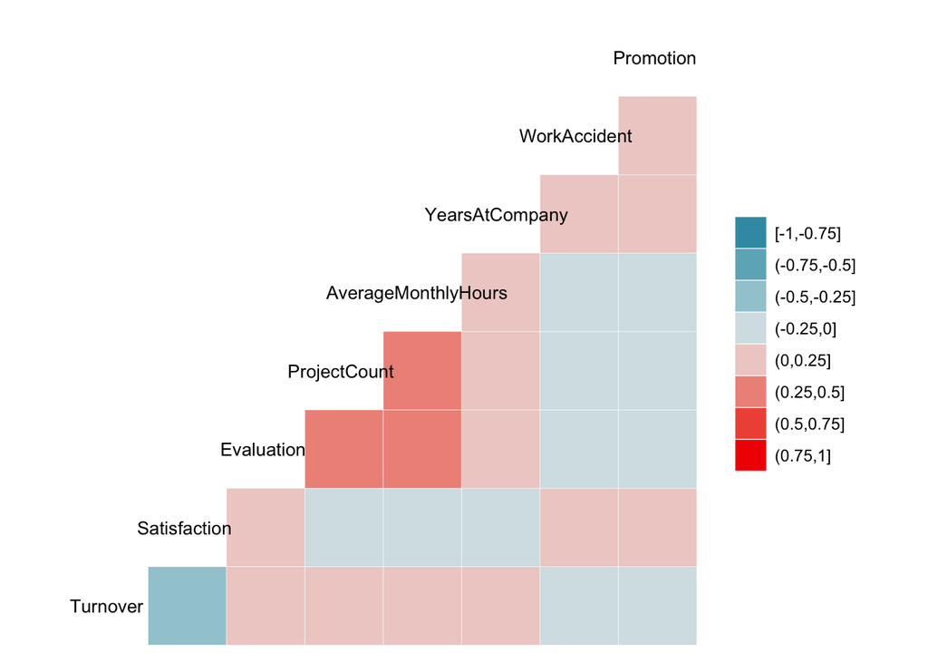

```r
library("GGally")
ggcorr(df[, c(-9,-10)], geom = "tile", nbreaks = 8, hjust = 0.53, size = 3.5)
```

### 3b.2 Statistical Test for Correlation

#### One-Sample T-Test (Measuring Satisfaction Level)

The Satisfaction has the higest correlation with the dependent variable Turnover, thus I will make a one- sample t-test to see whether the average satisfaction level of employees that had a turnover differs from those that had no turnover.

**Hypthesis Testing:** Is there any significant difference in the means of satisfaction level between employees who had a turnover and the employees who had no turnover?

- **Null Hypothesis:** (H0: pTS = pES) The null hyphothesis would be that **no** difference in satisfaction level between employees who did turnover and those who did not.
- **Alternative Hyphothesis:** (HA: pTS != pES) The alterantive hyphothesis would be that there is a difference in satisfaction level between employees who did turnover and those who did not.

```r
stayed_emp <- subset(df, Turnover == 0)
left_emp <- subset(df, Turnover == 1)

stayed_emp_satisfaction <- round(mean(stayed_emp$Satisfaction), 3)
left_emp_satisfaction <- round(mean(left_emp$Satisfaction), 3)
population_satisfaction <- round(mean(df$Satisfaction), 3)

print(paste("The mean satisfaction for the employee with no turnover is:", stayed_emp_satisfaction))
```

```
## [1] "The mean satisfaction for the employee with no turnover is: 0.667"
```

```r
print(paste("The mean satisfaction for the employee that had a turnover is:", left_emp_satisfaction))
```

```
## [1] "The mean satisfaction for the employee that had a turnover is: 0.44"
```

```r
print(paste("The mean satisfaction for the all employee is:", population_satisfaction))
```

```
## [1] "The mean satisfaction for the all employee is: 0.613"
```

#### Conducting the T-Test

```r
t.test(left_emp$Satisfaction, mu = stayed_emp_satisfaction)
```

```
##
##  One Sample t-test
##
## data:  left_emp$Satisfaction
## t = -51.373, df = 3570, p-value < 2.2e-16
## alternative hypothesis: true mean is not equal to 0.667
## 95 percent confidence interval:
##  0.4314385 0.4487576
## sample estimates:
## mean of x
##  0.440098
```

### T-Test Result

The test result shows that **the test statistic “t” is equal to -51.373**.This test statistic tells us how much the sample mean deviates from the null hypothesis. If the t-statistic lies outside the quantiles of the t-distribution corresponding to our confidence level and degrees of freedom, we reject the null hypothesis.

### T-Test Quantile

```r
# Degree of freedom
dof <- sum(as.numeric(left_emp$Turnover))

lq <- qt(0.025, dof)  # left quantile
rq <- qt(0.975, dof) # right quantile

print(paste("The t-distribution left quartile range is: ", lq))
```

```
## [1] "The t-distribution left quartile range is:  -1.96062852159556"
```

```r
print(paste("The t-distribution right quartile range is: ", rq))
```

```
## [1] "The t-distribution right quartile range is:  1.96062852159556"
```

### One-Sample T-Test Summary

T-Test = -51.37 | P-Value = 2.2e-16 | Reject Null Hypothesis

### 3c. Distribution Plots (Satisfaction - Evaluation - AverageMonthlyHours)

**Summary:** * Satisfaction: There is a huge spike for employees in both low and high satisfaction. * Evaluation: There is a bimodal of employee evaluation for low evaluations (less than 0.6) and high evalutions (higher than 0.8). * AverageMonthlyHours: There is a bimodal of employee average monthly hours for low and high hours ( less than 150 hours & higher than 250 hours). * The distribution of Evaluation and AverageMonthlyHours are very similiar. * Employees with higher AverageMonthlyHours have higher evaluation

### ???? difference between ggplot historgram and hist()? how to choose propriate breaks?

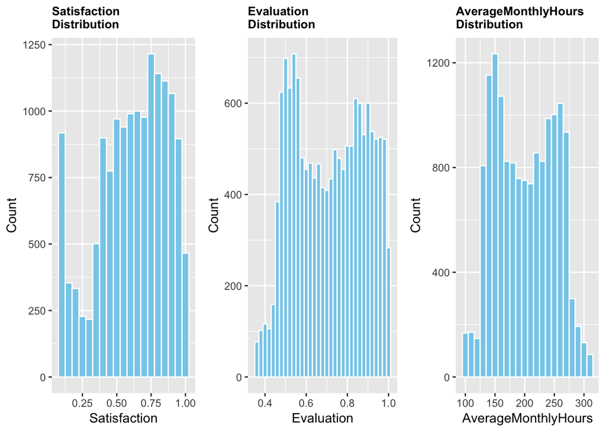

```r
# Import Packages
library(ggplot2)
library(grid)
library(gridExtra)

# Plot Satisfaction, Evaluation,
for (i in c("Satisfaction", "Evaluation", "AverageMonthlyHours")) {
  sub_df <- df[, i]
  breaks <- pretty(range(sub_df),
        n = nclass.FD(sub_df),
        min.n = 1)
  bwidth <- breaks[2]-breaks[1]
  assign(paste("p_", i, sep = ""),
         ggplot(df) + aes_string(i) +
           geom_histogram(binwidth = bwidth, fill="sky blue", color = "white") +
           ggtitle(paste(i, "\nDistribution")) +
           ylab("Count") +
           theme(plot.title = element_text(size = 10, face = "bold")))
}

grid.arrange(p_Satisfaction, p_Evaluation, p_AverageMonthlyHours, nrow = 1)
```

### 3d. Salary v.s. Turnover

**Summary:**

- Majority who left have a low and medium salary level.
- Only few of employees with high salary level left.
- Employees with lower salary are more likely to leave.

```r
# Create Summary Table
countST <- table(df$Turnover, df$SalaryLevel)
countST
```

```
##
##     high  low medium
##   0 1155 5144   5129
##   1   82 2172   1317
```

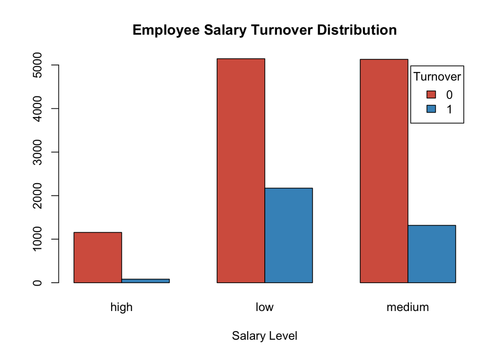

```r
# Draw Distribution Plot of Salary and Turnover
barplot(countST, main = "Employee Salary Turnover Distribution",
        xlab = "Salary Level", col = c("#D6604D", "#4393C3"),
        legend = rownames(countST),
        args.legend = list("title" = "Turnover"),
        beside = TRUE)
```

## 3e. Department v.s. Turnover

**Summary**:

- Technical, support and sales are the top3 department have employees turnover.
- Management has the fewest employees turnover.
- The more employees in a department, the more employees in this department left. In other words, the number of employees turnover in a department is positively related to the number of employees in that department.

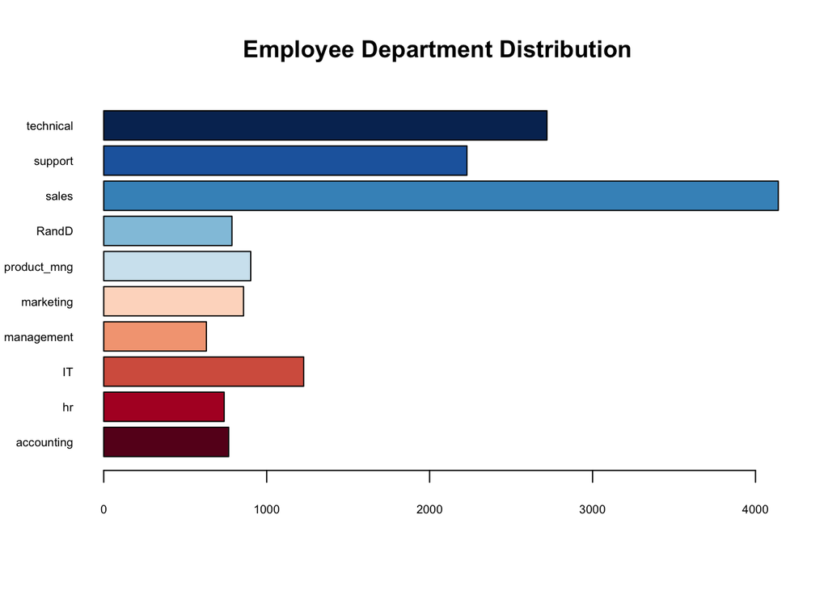

```r
library(RColorBrewer)
countD <- table(df$Department)
# Create Distribution Plot of Department
barplot(countD, main = "Employee Department Distribution",
        col = brewer.pal(10, "RdBu"),
        # ylab = "Department",
        las = 1, cex.names = 0.6, cex.axis = 0.6,
        horiz = TRUE)
```

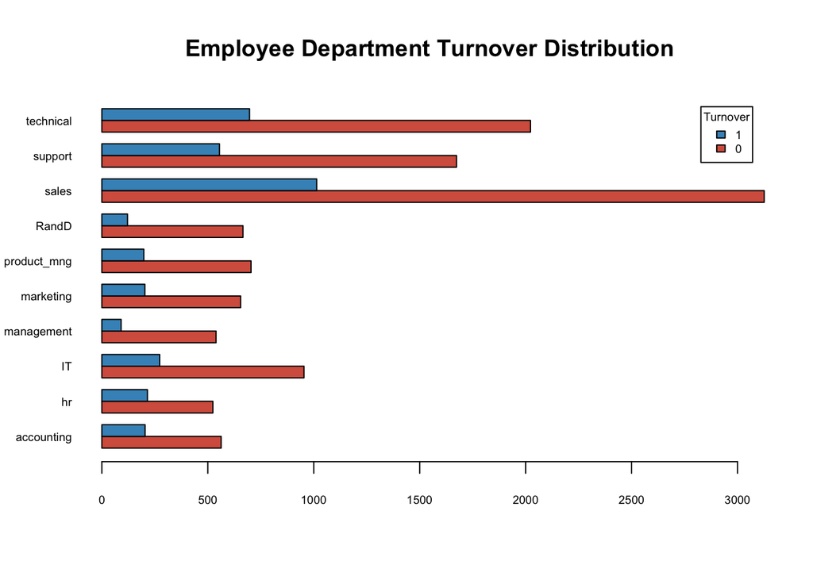

```r
countDT <- table(df$Turnover, df$Department)
# Draw Distribution Plot of Department Turnover
barplot(countDT, main = "Employee Department Turnover Distribution",
        col = c("#D6604D", "#4393C3"),
        # ylab = "Department",
        las = 1, cex.names = 0.6, cex.axis = 0.6,
        legend = rownames(countDT),
        args.legend = list("title" = "Turnover", cex = 0.6),
        beside = TRUE, horiz = TRUE)
```